# Chapter 2 - exercise 2: Petrol consumption

### Cho dữ liệu petrol_consumption.csv

### Hãy áp dụng Linear Regression để dự đoán Petrol_Consumption dựa trên Petrol_tax, Average_income, Paved_Highways, Population_Driver_licence(%)

1. Đọc dữ liệu. Xem thông tin data về dữ liệu. Chuẩn hóa dữ liệu nếu cần.
2. Vẽ viểu đồ quan sát mối liên hệ giữa các biến Petrol_Consumption, Petrol_tax, Average_income, Paved_Highways, Population_Driver_licence(%)
3. Tạo inputs data và outputs data => Tạo X_train, X_test, y_train, y_test với tỷ lệ 80:20
4. Thực hiện Linenear Regression với X_train, y_train
5. Dự đoán y từ X_test => so sánh với y_test
6. Tính Coefficients, Intercept và Variance score, MSE
7. Vẽ hình và xem kết quả
8. Nhận xét dựa trên kết quả, có giải pháp nào để kết quả tốt hơn không?

```python
from google.colab import drive
drive.mount("/content/gdrive", force_remount=True)

path = '/content/gdrive/My Drive/LDS6_MachineLearning/'
```

[output not shown]

```python
import numpy as np
import pandas as pd
import matplotlib.pyplot as plt
```

```python
data = pd.read_csv(path + "practice/Chapter2_Linear_Regression/petrol_consumption.csv", sep=",")
```

```python
print(data.shape)
type(data)
```

```
(48, 5)
```

```
pandas.core.frame.DataFrame
```

```python
data.dtypes
```

```
Petrol_tax                      float64
Average_income                    int64
Paved_Highways                    int64
Population_Driver_licence(%)    float64
Petrol_Consumption                int64
dtype: object
```

```python
data.head()
```

|  | Petrol_tax | Average_income | Paved_Highways | Population_Driver_licence(%) | Petrol_Consumption |
| --- | --- | --- | --- | --- | --- |
| 0 | 9.0 | 3571 | 1976 | 0.525 | 541 |
| 1 | 9.0 | 4092 | 1250 | 0.572 | 524 |
| 2 | 9.0 | 3865 | 1586 | 0.580 | 561 |
| 3 | 7.5 | 4870 | 2351 | 0.529 | 414 |
| 4 | 8.0 | 4399 | 431 | 0.544 | 410 |

```python
data.describe()
```

|  | Petrol_tax | Average_income | Paved_Highways | Population_Driver_licence(%) | Petrol_Consumption |
| --- | --- | --- | --- | --- | --- |
| count | 48.000000 | 48.000000 | 48.000000 | 48.000000 | 48.000000 |
| mean | 7.668333 | 4241.833333 | 5565.416667 | 0.570333 | 576.770833 |
| std | 0.950770 | 573.623768 | 3491.507166 | 0.055470 | 111.885816 |
| min | 5.000000 | 3063.000000 | 431.000000 | 0.451000 | 344.000000 |
| 25% | 7.000000 | 3739.000000 | 3110.250000 | 0.529750 | 509.500000 |
| 50% | 7.500000 | 4298.000000 | 4735.500000 | 0.564500 | 568.500000 |
| 75% | 8.125000 | 4578.750000 | 7156.000000 | 0.595250 | 632.750000 |
| max | 10.000000 | 5342.000000 | 17782.000000 | 0.724000 | 968.000000 |

```python
import matplotlib.pyplot as plt
import seaborn as sns
```

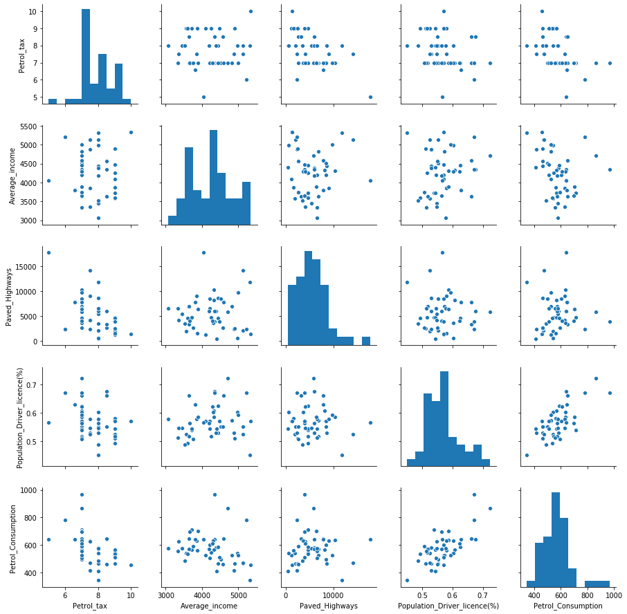

```python
sns.pairplot(data)
plt.show()
```

```python
inputs = data[['Petrol_tax', 'Average_income', 'Paved_Highways',
       'Population_Driver_licence(%)']]
print(type(inputs))
inputs.head()
```

```
<class 'pandas.core.frame.DataFrame'>
```

|  | Petrol_tax | Average_income | Paved_Highways | Population_Driver_licence(%) |
| --- | --- | --- | --- | --- |
| 0 | 9.0 | 3571 | 1976 | 0.525 |
| 1 | 9.0 | 4092 | 1250 | 0.572 |
| 2 | 9.0 | 3865 | 1586 | 0.580 |
| 3 | 7.5 | 4870 | 2351 | 0.529 |
| 4 | 8.0 | 4399 | 431 | 0.544 |

```python
outputs = data['Petrol_Consumption']
print(type(outputs))
outputs.head()
```

```
<class 'pandas.core.series.Series'>
```

```
0    541
1    524
2    561
3    414
4    410
Name: Petrol_Consumption, dtype: int64
```

```python
from sklearn.model_selection import train_test_split
from sklearn import datasets, linear_model, metrics
from sklearn.metrics import mean_squared_error, r2_score
```

```python
X_train, X_test, y_train, y_test = train_test_split(inputs, outputs, test_size=0.20, random_state = 42)
regr = linear_model.LinearRegression()
regr = regr.fit(X_train, y_train)
```

```python
y_pred = regr.predict(X_test)
```

```python
df = pd.DataFrame({'Actual': pd.Series(y_test.values), 'Prediction': pd.DataFrame(y_pred)[0].values})
df.head()
```

|  | Actual | Prediction |
| --- | --- | --- |
| 0 | 631 | 606.692665 |
| 1 | 587 | 673.779442 |
| 2 | 577 | 584.991490 |
| 3 | 591 | 563.536910 |
| 4 | 460 | 519.058672 |

```python
# The coefficients
print('Coefficients: \n', regr.coef_)
print('Intercept: \n', regr.intercept_)
```

```
Coefficients:
 [-3.69937459e+01 -5.65355145e-02 -4.38217137e-03  1.34686930e+03]
Intercept:
 361.45087906653225
```

```python
# The mean squared error
print("Mean squared error: %.2f"
      % mean_squared_error(outputs, regr.predict(inputs)))
# Explained variance score: 1 is perfect prediction
print('Variance score: %.2f' % regr.score(inputs, outputs))
```

```
Mean squared error: 4029.43
Variance score: 0.67
```

''' Ta có thể thấy rằng mô hình chỉ khái quát được ~67% dữ liệu, MSE lớn => Điều này có nghĩa là thuật toán không chính xác lắm (nhưng vẫn có thể đưa ra những dự đoán hợp lý) Một số yếu tố có thể đã góp phần vào sự không chính xác này, đó là:

- Cần thêm dữ liệu: Chỉ có một năm giá trị của dữ liệu nên chưa đủ lớn
- Giả định xấu: khi đưa giả thiết rằng dữ liệu này có mối quan hệ tuyến tính => nhưng điều đó có thể không đúng. (Trực quan hóa dữ liệu có thể giúp ta xác định điều này)
- Tính năng kém: Các tính năng sử dụng có thể không có tương quan đủ cao với các giá trị ta đang cố gắng dự đoán. '''

```python
print('Variance score: %.2f' % metrics.r2_score(y_test, y_pred))
```

```
Variance score: 0.39
```

```python
# Check the score of train and test
regr.score(X_train, y_train)
```

```
0.7068781342155135
```

```python
regr.score(X_test, y_test)
```

```
0.3913664001428886
```

Chúng ta thấy R^2 cho dữ liệu huấn luyện là 0.70 trong khi R^2 trên dữ liệu thử nghiệm là 0.39. (Chú ý: R^2 càng thấp, mô hình càng tệ, R^2 âm là dấu hiệu của overfitting).  
Cần suy nghĩ về các thuộc tính áp dụng để huấn luyện mô hình, lựa chọn lại nếu cần!

```python
# Trực quan hóa kết quả
```

```python
# Có giải pháp nào tốt hơn không???
```

# Polinominal

```python
from sklearn.preprocessing import PolynomialFeatures
```

```python
pr=PolynomialFeatures(degree=2)
pr
```

```
PolynomialFeatures(degree=2, include_bias=True, interaction_only=False,
                   order='C')
```

```python
X_pr=pr.fit_transform(inputs)
```

```python
inputs.shape, X_pr.shape
```

```
((48, 4), (48, 15))
```

```python
X_train_n, X_test_n, y_train_n, y_test_n = train_test_split(X_pr, outputs, test_size=0.20, random_state = 42)
regr_n = linear_model.LinearRegression()
regr_n = regr.fit(X_train_n, y_train_n)
```

```python
y_pred_n = regr_n.predict(X_test_n)
```

```python
df_n = pd.DataFrame({'Actual': pd.Series(y_test_n.values), 'Prediction': pd.DataFrame(y_pred_n)[0].values})
df_n.head()
```

|  | Actual | Prediction |
| --- | --- | --- |
| 0 | 631 | 598.219347 |
| 1 | 587 | 684.951003 |
| 2 | 577 | 572.904670 |
| 3 | 591 | 580.529789 |
| 4 | 460 | 516.369764 |

```python
# The coefficients
print('Coefficients: \n', regr_n.coef_)
print('Intercept: \n', regr_n.intercept_)
```

```
Coefficients:
 [ 0.00000000e+00  1.20673524e+02 -4.13821515e-01 -1.20872819e-02
  3.10230312e+03 -8.21479544e-01  5.97669723e-02  4.85835297e-03
 -7.28338625e+02 -6.11311088e-05  4.90434139e-06  6.13752963e-01
  1.37119619e-06 -1.19102672e-01  1.62695640e+03]
Intercept:
 86.34280461569125
```

```python
# The mean squared error
print("Mean squared error: %.2f"
      % mean_squared_error(outputs, regr_n.predict(X_pr)))
# Explained variance score: 1 is perfect prediction
print('Variance score: %.2f' % regr_n.score(X_pr, outputs))
```

```
Mean squared error: 2694.08
Variance score: 0.78
```

```python
# Check the score of train and test
regr_n.score(X_train_n, y_train_n)
```

```
0.83445301125447
```

```python
regr_n.score(X_test_n, y_test_n)
```

```
0.3569314648221876
```

Chúng ta thấy R^2 cho dữ liệu huấn luyện là 0.83 trong khi R^2 trên dữ liệu thử nghiệm là 0.35. => Overfitting (Chú ý: R^2 càng thấp, mô hình càng tệ, R^2 âm là dấu hiệu của overfitting).  
Cần suy nghĩ về các thuộc tính áp dụng để huấn luyện mô hình, lựa chọn lại nếu cần!

```python
y_train_hat_n = regr_n.predict(X_train_n)
y_test_hat_n = regr_n.predict(X_test_n)
```

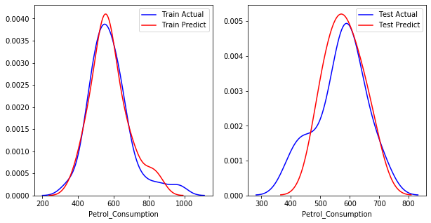

```python
plt.figure(figsize=(10,5))
plt.subplot(1, 2, 1)
ax1 = sns.distplot(y_train_n, hist=False, color="b", label='Train Actual')
sns.distplot(y_train_hat_n, hist=False, color="r", label='Train Predict', ax=ax1)
plt.subplot(1,2,2)
ax2 = sns.distplot(y_test_n, hist=False, color="b", label='Test Actual')
sns.distplot(y_test_hat_n, hist=False, color="r", label='Test Predict', ax=ax2)
plt.show()
```

# Select important features

```python
from sklearn.feature_selection import SelectKBest
from sklearn.feature_selection import f_regression
```

```python
#apply SelectKBest class to extract top 10 best features
bestfeatures = SelectKBest(score_func=f_regression, k='all')
fit = bestfeatures.fit(inputs,outputs)
dfscores = pd.DataFrame(fit.scores_)
dfcolumns = pd.DataFrame(inputs.columns)
```

```python
#concat two dataframes for better visualization
featureScores = pd.concat([dfcolumns,dfscores],axis=1)
featureScores.columns = ['Specs','Score']  #naming the dataframe columns
print(featureScores.nlargest(4,'Score'))  #print 4 best features
```

```
                          Specs      Score
3  Population_Driver_licence(%)  43.940833
0                    Petrol_tax  11.763828
1                Average_income   2.933954
2                Paved_Highways   0.016685
```

```python
# Chọn Population_Driver_licence(%), Petrol_tax, Average_income ???
```

```python
# Làm lại model, xem kết quả
```

```python
from sklearn.ensemble import ExtraTreesRegressor
```

```python
model = ExtraTreesRegressor()
model.fit(inputs,outputs)
```

```
ExtraTreesRegressor(bootstrap=False, criterion='mse', max_depth=None,
                    max_features='auto', max_leaf_nodes=None,
                    min_impurity_decrease=0.0, min_impurity_split=None,
                    min_samples_leaf=1, min_samples_split=2,
                    min_weight_fraction_leaf=0.0, n_estimators=10, n_jobs=None,
                    oob_score=False, random_state=None, verbose=0,
                    warm_start=False)
```

```
[0.15377221 0.22425752 0.11163942 0.51033085]
```

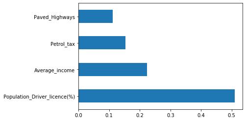

```python
print(model.feature_importances_) #use inbuilt class feature_importances of tree based regressor
#plot graph of feature importances for better visualization
feat_importances = pd.Series(model.feature_importances_, index=inputs.columns)
feat_importances.nlargest(4).plot(kind='barh')
plt.show()
```

```python
# Chọn Population_Driver_licence(%), Average_income, Petrol_tax ???
```

```python
corrmat = data.corr()
top_corr_features = corrmat.index
```

```python
data.corr()
```

|  | Petrol_tax | Average_income | Paved_Highways | Population_Driver_licence(%) | Petrol_Consumption |
| --- | --- | --- | --- | --- | --- |
| Petrol_tax | 1.000000 | 0.012665 | -0.522130 | -0.288037 | -0.451280 |
| Average_income | 0.012665 | 1.000000 | 0.050163 | 0.157070 | -0.244862 |
| Paved_Highways | -0.522130 | 0.050163 | 1.000000 | -0.064129 | 0.019042 |
| Population_Driver_licence(%) | -0.288037 | 0.157070 | -0.064129 | 1.000000 | 0.698965 |
| Petrol_Consumption | -0.451280 | -0.244862 | 0.019042 | 0.698965 | 1.000000 |

```python
# Chọn Population_Driver_licence(%), Petrol_tax, Average_income ???
```

```python
inputs_n = data[['Petrol_tax',
       'Population_Driver_licence(%)']]
```

```python
outputs_n = data['Petrol_Consumption']
```

```python
X_train_, X_test_, y_train_, y_test_ = train_test_split(inputs_n, outputs_n, test_size=0.20, random_state = 42)
regr_ = linear_model.LinearRegression()
regr_ = regr.fit(X_train_, y_train_)
```

```python
y_pred_ = regr_.predict(X_test_)
```

```python
df_ = pd.DataFrame({'Actual': pd.Series(y_test_.values), 'Prediction': pd.DataFrame(y_pred_)[0].values})
df_.head()
```

|  | Actual | Prediction |
| --- | --- | --- |
| 0 | 631 | 595.975095 |
| 1 | 587 | 674.071029 |
| 2 | 577 | 539.523243 |
| 3 | 591 | 514.445923 |
| 4 | 460 | 529.065066 |

```python
# The coefficients
print('Coefficients: \n', regr_.coef_)
print('Intercept: \n', regr_.intercept_)
```

```
Coefficients:
 [ -29.03288495 1352.75514135]
Intercept:
 30.476505362572766
```

```python
# The mean squared error
print("Mean squared error: %.2f"
      % mean_squared_error(outputs, regr_.predict(inputs_n)))
# Explained variance score: 1 is perfect prediction
print('Variance score: %.2f' % regr_.score(inputs_n, outputs_n))
```

```
Mean squared error: 5470.69
Variance score: 0.55
```

```python
# Check the score of train and test
regr_.score(X_train_, y_train_)
```

```
0.6045745037360575
```

```python
regr_.score(X_test_, y_test_)
```

```
0.15394880930477928
```

```python
# khong tot hon !!!
```